# Compare internal vs pooled references: SCPCP000015

Stephanie J. Spielman

2025-06-03

## Introduction

For several samples in `SCPCP000015`, we were able to run `inferCNV` with a so-called “internal” normal reference, where normal cells were taken only from the library being analyzed and were not pooled across all libraries. The goal of this notebook is to directly compare results from internal references with their pooled counterparts to assess if there is evidence that the pooled reference strategy improves tumor/normal classification.

## Setup

```r
options(readr.show_col_types = FALSE)
suppressPackageStartupMessages({
  library(ggplot2)
  library(SingleCellExperiment)
})

theme_set(theme_bw())
```

### Functions

This function prepares a table of `inferCNV` results by creating a `total_cnv_per_cell` column to summarize CNVs per cell.

```r
prepare_cnv_df <- function(infercnv_tsv) {
  infercnv_df <- readr::read_tsv(infercnv_tsv)

  infercnv_metadata_df <- infercnv_df |>
    dplyr::select(
      -starts_with("has_"),
      -starts_with("proportion_"),
      -starts_with("top_")
    ) |>
    dplyr::mutate(cell_group = stringr::str_split_i(subcluster, "_", 1))

  infercnv_df |>
    tidyr::pivot_longer(
      starts_with("has_cnv_"),
      names_to = "chr",
      values_to = "cnv"
    ) |>
    # sum all values for each
    dplyr::group_by(cell_id) |>
    dplyr::summarize(total_cnv_per_cell = sum(cnv)) |>
    dplyr::ungroup() |>
    # bring back metadata
    dplyr::inner_join(
      infercnv_metadata_df,
      by = "cell_id"
    )
}
```

This function plots ridge plots of total CNV values across cell groupings, faceted by reference type (pooled vs. internal) and library id, for a given reference cell grouping.

```r
plot_cnv_distributions <- function(reference_name, df) {
  df <- infercnv_df |>
    dplyr::filter(
      reference_cell_group == reference_name
    )
  ggplot(df) +
    aes(x = total_cnv_per_cell, y = label, fill = label) +
    ggridges::geom_density_ridges2(scale = 0.9) +
    facet_grid(
      cols = vars(library_id),
      rows = vars(reference_type)
    ) +
    theme(legend.position = "none") +
    ggtitle(
      glue::glue("Comparing {reference_name} internal vs. pooled")
    )
}
```

### Paths

#### Base directories

```r
# The base path for the OpenScPCA repository, found by its (hidden) .git directory
repository_base <- rprojroot::find_root(rprojroot::is_git_root)

module_dir <- file.path(repository_base, "analyses", "infercnv-consensus-cell-type")
result_dir <- file.path(module_dir, "results", "SCPCP000015") # organized as sample/reference/infercnv results
ewings_dir <- file.path(repository_base, "data", "current", "results", "cell-type-ewings", "SCPCP000015")
```

#### Input files

```r
# inferCNV output files
infercnv_files <- list.files(
  path = result_dir,
  pattern = "_cnv-metadata\\.tsv",
  recursive = TRUE,
  full.names = TRUE
) |>
  # we only want internal here.
  # based on these internals, we'll also grab corresponding pooled
  purrr::keep(\(x) {
    stringr::str_detect(x, "internal")
  })


infercnv_files <- c(
  infercnv_files,
  stringr::str_replace(infercnv_files, "internal", "pooled")
) |>
  # name by library id
  purrr::set_names(\(x) {
    library_id <- stringr::str_split_i(basename(x), "_", 1)
  })



# ewing module cell types
celltype_files <- list.files(
  ewings_dir,
  pattern = "_ewing-celltype-assignments\\.tsv",
  recursive = TRUE,
  full.names = TRUE
) |>
  # name by library id
  purrr::set_names(\(x) {
    stringr::str_split_i(basename(x), "_", 1)
  })
```

### Read input files

We’ll first read in the cell type annotations:

```r
celltype_df <- celltype_files |>
  purrr::map(readr::read_tsv) |>
  purrr::list_rbind(names_to = "library_id") |>
  dplyr::mutate(cell_id = glue::glue("{library_id}-{barcodes}")) |>
  dplyr::select(cell_id, consensus_annotation, ewing_annotation)
```

Next we’ll read in and prepare the `inferCNV` results:

```r
infercnv_df <- infercnv_files |>
  purrr::map(prepare_cnv_df) |>
  purrr::list_rbind(names_to = "library_id") |>
  dplyr::inner_join(celltype_df, by = "cell_id") |>
  # split normal_reference into "reference_cell_group" and "reference_type"
  tidyr::separate(
    normal_reference,
    into = c("reference_cell_group", "reference_type"),
    sep = "_",
    remove = FALSE # keep the normal_reference column around
  ) |>
  # condense labels for cell type groupings
  dplyr::mutate(
    label = ifelse(
      stringr::str_detect(ewing_annotation, "tumor"),
      "tumor",
      cell_group
    ),
    label = forcats::fct_relevel(label, "unknown", "tumor", "reference")
  )
```

## Visualization

We’ll plot the total CNV distributions for each inference for each grouping of cells:

- `unknown`: query cells
- `tumor`: query cells labeled “tumor” by `cell-type-ewings`
- `reference`: cells in the normal reference

We’ll plot this separately for each reference cell group (`endo`, `immune`, and `endo-immune`) for visual ease to make comparisons between `internal` and `pooled` reference versions. Note that `SCPCL001112` was only run with an `endo` internal reference since it didn’t have sufficient immune cells; this library will therefore only appear in the plots for the `endo` reference.

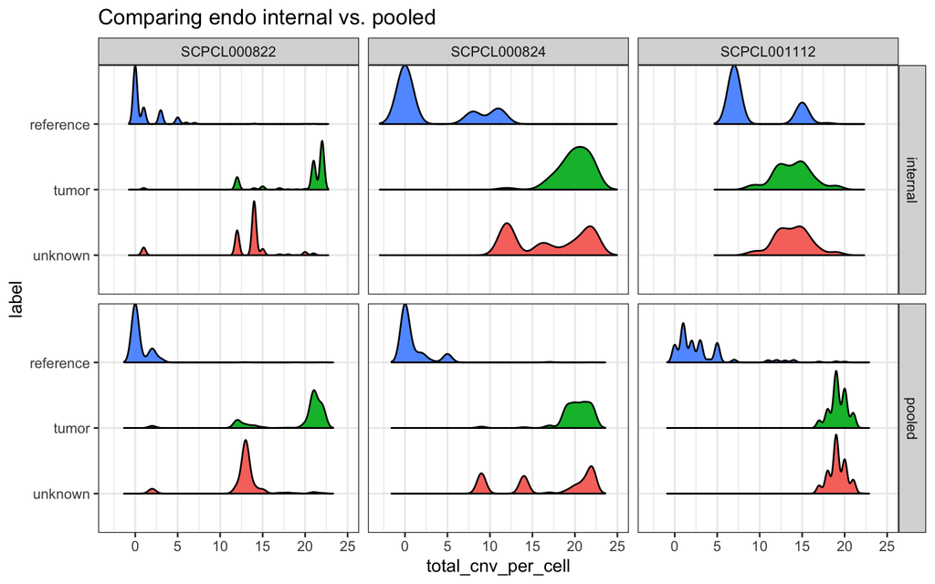

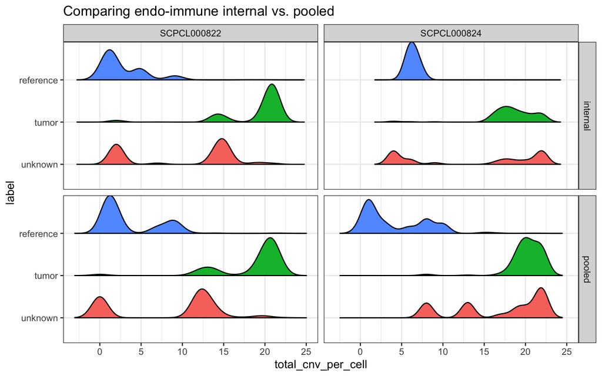

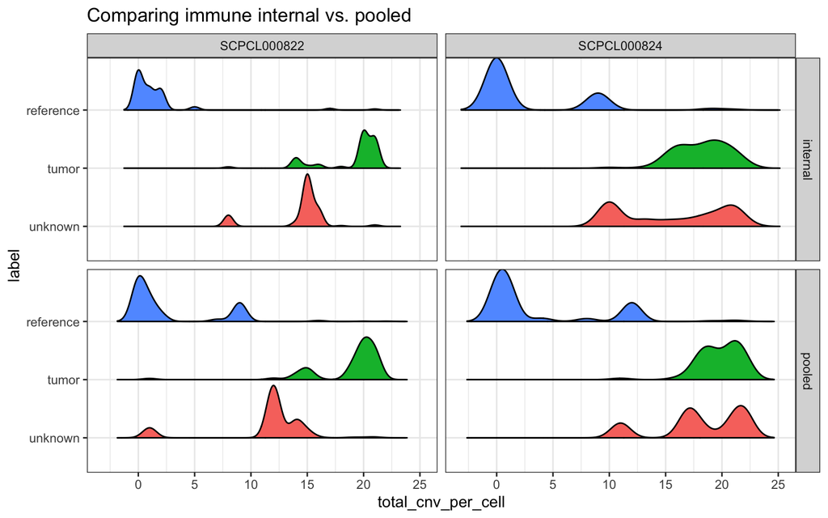

```r
unique(infercnv_df$reference_cell_group) |>
  purrr::map(plot_cnv_distributions, infercnv_df)
```

## Conclusions

- For all three libraries we were able to directly compare internal and pooled references for, the pooled reference appears to do either a similar or slightly a better job separating normal and tumor cells compared to the internal reference.
- There is no obvious inference where using a pooled reference appears *worse* than using an internal reference.
- Similar to previous observations we’ve made, the `endo` reference (either pooled or internal) shows improved separation between tumor and normal compared to references containing `immune` cells.
- Notably, `SCPCL001112` is a much smaller library than `SCPCL000822` and `SCPCL000824`, and we see evidence here that using a pooled reference dramatically improves separation between tumor and normal.

Overall, these comparisons suggest that using a pooled reference is a reasonable approach, in particular when information is limited within a single library.